# Alexander Lake, Windham County, CT, USA Report

*Report Last Updated: May 2026*

## Program Information

The Connecticut Lake Watch network is a statewide volunteer (i.e., community science) water quality monitoring program coordinated by the Connecticut Department of Energy and Environmental Protection (DEEP) as part of the larger [Connecticut Volunteer Water Monitoring Program.](https://portal.ct.gov/DEEP/Water/Inland-Water-Monitoring/Volunteer-Water-Monitoring-Program) Connecticut Lake Watch participants are trained to monitor lake/pond water clarity using a Secchi disk and thermometer. Monitoring ideally occurs weekly from early spring until fall.

## Station Location

[interactive chart not shown]

## Secchi Depth Data

Below, you can toggle between daily average and yearly average secchi depth values. The graphs have been scaled to the approximate maximum depth of the waterbody, represented by the horizontal dotted line.

Eutrophic

Mesotrophic

Oligotrophic

### Daily Average

[interactive chart not shown]

### Yearly Average

[interactive chart not shown]

## Water Temperature Data

There is no surface water temperature data available for this lake.

## How Does Your Lake Compare?

The graphs below shows how your lake ranks compared to data collected by CT DEEP over the past 10 years, across all lakes in the state. For Secchi Depth, an upper percentile indicates that your lake has higher water clarity*.

Eutrophic

Mesotrophic

Oligotrophic

Your Lake’s Average

Your lake’s average Secchi Depth falls in the **above the 75th percentile** of all lakes sampled in CT by DEEP in the last 10 years.  
The max depth of your lake is **13.7 meters** .

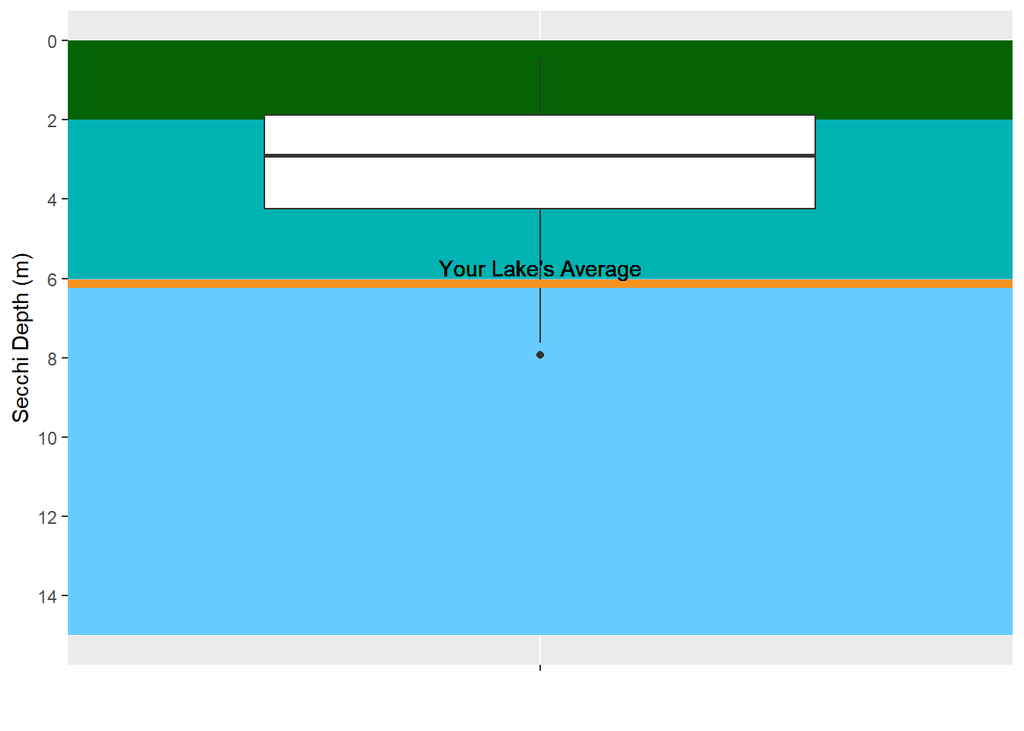

*Water clarity refers to the clearness or transparency of water and is affected by particles in the water column. Water clarity is determined by using a 20 cm disk called a Secchi disk. The maximum depth that the Secchi disk can be seen from the surface is the Secchi depth value. Secchi depth can be used to estimate the trophic status of a waterbody. Secchi depth can vary based on natural and anthropogenic (human) conditions in and around lakes. For more information see CT DEEP’s Citizen’s Guide to Lake Monitoring.